# Quark/gluon jet discrimination: a reproducible analysis using R

### Andrew John Lowe

#### Wigner Research Centre for Physics, Hungarian Academy of Sciences

#### 3 April 2017

# Overview

- This talk will present a walk-through of the development of a prototype machine learning classifier for differentiating between quark and gluon jets at experiments like those at the LHC.
- A new fast feature selection method that combines information theory and graph analytics will be outlined. This method has found new variables that promise significant improvements in discrimination power.
- The prototype jet tagger is simple, interpretable, parsimonious, and computationally extremely cheap, and therefore might be suitable for use in trigger systems for real-time data processing.
- The data analysis was performed entirely in the R statistical programming language, and is fully reproducible. The entire analysis workflow is data-driven, automated and runs on very modest hardware with no human intervention.

# The problem in a nutshell

- Beams of energetic protons collide inside our detector
- Quarks and gluons emerge and decay into sprays of particles
- Algorithms cluster these decay products into jets
- For each jet, we’d like to know what initiated it:
  - *Was it a quark or a gluon?*
- Being able to accurately discriminate between quark- and gluon-initiated jets would be an extremely powerful tool in the search for new particles and new physics
- This is an archetypal classification problem that might be amenable to machine learning

# What is machine learning?

- Arthur Samuel (1959): Field of study that gives computers the ability to learn without being explicitly programmed
- Tom Mitchell (1998): A computer program is said to learn from experience *E* with respect to some task *T* and some performance measure *P*, if its performance on *T*, as measured by *P*, improves with experience *E*
- Traditional programming versus machine learning:

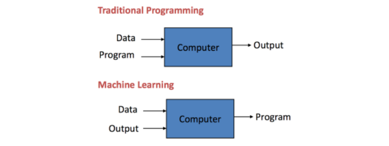

# Machine learning & HEP

- Machine learning is more or less what is commonly known in particle physics as multivariate analysis (MVA)
- Used for many years but faced widespread scepticism
- Use of multivariate pattern recognition algorithms was basically taboo in new particle searches until recently
- Much prejudice against using what were considered “black box” selection algorithms
- Artificial neural networks and Fisher discriminants (linear discriminant analysis) were used somewhat in the 1990’s
- Boosted Decision Tree (AdaBoost, 1996) is the favourite algorithm used for many analyses (1st use: 2004)

[Successes, Challenges and Future Outlook of Multivariate Analysis In HEP](http://iopscience.iop.org/article/10.1088/1742-6596/608/1/012058/meta), Helge Voss, 2015 J. Phys.: Conf. Ser. 608 (2015) 012058; [Higgs Machine Learning Challenge visits CERN](http://indico.cern.ch/event/382895/), 19 May 2015, CERN; [Boosted Decision Trees as an Alternative to Artificial Neural Networks for Particle Identification](http://arxiv.org/abs/physics/0408124), Hai-Jun Yang *et al.*, Nucl.Instrum.Meth. A543 (2005) 577-584

# What is the goal of this work?

We want a simple, interpretable, parsimonious, preferably computationally cheap model that is informative and actually stands a reasonable chance of being deployed at some point in the future. We would also like to spend our limited CPU cycles on robust testing, rather than a complex model.

(This is not a Kaggle competition! Of course we care about model performance, but there are other important considerations.)

# Data production pipeline

- Generate Monte Carlo simulated data with lots of jets
  - *pp* at 7 TeV, Pythia 6
  - Jets reconstructed using FastJet, Anti-*k*ᴛ with a radial parameter of 0.4, and these serve as our “detector-level” objects
- Use my C++ code to fill ROOT ntuples with engineered features
- Attach ground-truth class labels (“quark”/“gluon”) to each jet
  - Significant class noise (mislabelled jets) at the 5–10% level
  - Procedure sometimes fails to assign class (missing labels)
  - Several labelling schemes exist, but none are perfect because Monte Carlo simulation cannot perfectly simulate real data
- Write-out data and convert for use in **R**

# Feature engineering

- Quick and easy to generate new variables, following example in$^*$:
- The procedure is:
  - Pick a particle
  - Pick a kinematic property
  - Pick a second particle
  - Optionally transform to a boosted frame
  - *etc.*
- This recipe results in a proliferation of many unintuitive combinations of variables
- *Many variables found during a very thorough literature search*
- Hundreds of experimentally motivated, physically motivated, and unmotivated single-variable discriminants

* “Multivariate discrimination and the Higgs + W/Z search”, Kevin Black, Jason Gallicchio, John Huth, Michael Kagan, Matthew D. Schwartz, Brock Tweedie, JHEP 1104:069,2011